# Discriminant Analysis

ChatGPT 4o

2025-01-21

## 1 起源

判别分析（Discriminant Analysis）是一种用于分类的统计方法，最早由罗纳德·费舍尔（Ronald Fisher）在1936年提出，旨在通过线性组合特征来最大化类间差异。最初，Fisher判别分析被用于分类鸢尾花数据集中的花种，并成为数据科学、模式识别和机器学习等领域中常用的分类方法之一。

## 2 原理

判别分析的基本原理是通过构建判别函数，将观测数据分配到事先已知的类别中。最常见的是线性判别分析（Linear Discriminant Analysis, LDA），其目的是寻找一个或多个线性组合，使得不同类别之间的方差最大化，而类内方差最小化。

判别函数的形式为：

$$D_k = a_0 + a_1 X_1 + a_2 X_2 + \cdots + a_p X_p$$

其中，$D_k$ 表示第 $k$ 类的判别得分，$X_1, X_2, \cdots, X_p$ 表示观测变量，$a_0, a_1, \cdots, a_p$ 为判别系数。判别分析根据每个样本的得分，将其分配到得分最高的类别。

## 3 适用范围

判别分析适用于以下情况：

- **分类任务**：用于对观测样本进行分类，适用于已知类别的分类任务。
- **多类分类**：判别分析可用于两个或多个类别的分类。
- **数据符合正态性假设**：判别分析假定每个类别的特征服从多元正态分布，并且类别之间具有相同的协方差矩阵。

## 4 应用情境

判别分析在多个领域都有广泛的应用，例如：

- **医学研究**：用于诊断疾病，将患者分类为不同的健康状态或疾病类型。
- **市场营销**：分析客户数据，将客户分为不同的群体，以制定相应的营销策略。
- **金融分析**：用于信用评估，将贷款申请者分为高风险和低风险群体。
- **生态学**：用于分类不同物种，根据特征变量将新样本分配到已知物种中。

## 5 优缺点

### 优点

- **简单易用**：线性判别分析具有简单的数学形式，计算效率高，容易实现。
- **多类分类**：可以同时处理多个类别的分类问题，而不仅限于二元分类。
- **数据降维**：LDA可以用于降维，寻找最能区分类别的线性组合，便于数据的可视化和理解。

### 缺点

- **对正态性假设敏感**：判别分析假设特征服从多元正态分布，若数据偏离该假设，分类效果可能会受到影响。
- **对协方差矩阵相同的假设**：LDA假设各类别具有相同的协方差矩阵，当该假设不满足时，模型性能会下降。
- **对异常值敏感**：判别分析对异常值较为敏感，异常值可能会对判别函数的构建产生较大影响。

## 6 在R中的实现及结果解释

在R中，可以使用`MASS`包中的`lda()`函数进行判别分析。以下是一个使用鸢尾花数据集的示例：

```r
# 加载必要的包
library(MASS)
library(ggplot2)

# 使用iris数据集
data <- iris

# 进行线性判别分析
lda_result <- lda(Species ~ ., data = data)

# 输出判别分析结果
print(lda_result)
```

```
## Call:
## lda(Species ~ ., data = data)
##
## Prior probabilities of groups:
##     setosa versicolor  virginica
##  0.3333333  0.3333333  0.3333333
##
## Group means:
##            Sepal.Length Sepal.Width Petal.Length Petal.Width
## setosa            5.006       3.428        1.462       0.246
## versicolor        5.936       2.770        4.260       1.326
## virginica         6.588       2.974        5.552       2.026
##
## Coefficients of linear discriminants:
##                     LD1         LD2
## Sepal.Length  0.8293776 -0.02410215
## Sepal.Width   1.5344731 -2.16452123
## Petal.Length -2.2012117  0.93192121
## Petal.Width  -2.8104603 -2.83918785
##
## Proportion of trace:
##    LD1    LD2
## 0.9912 0.0088
```

```r
summary(lda_result)
```

```
##         Length Class  Mode
## prior    3     -none- numeric
## counts   3     -none- numeric
## means   12     -none- numeric
## scaling  8     -none- numeric
## lev      3     -none- character
## svd      2     -none- numeric
## N        1     -none- numeric
## call     3     -none- call
## terms    3     terms  call
## xlevels  0     -none- list
```

```r
str(lda_result)
```

```
## List of 10
##  $ prior  : Named num [1:3] 0.333 0.333 0.333
##   ..- attr(*, "names")= chr [1:3] "setosa" "versicolor" "virginica"
##  $ counts : Named int [1:3] 50 50 50
##   ..- attr(*, "names")= chr [1:3] "setosa" "versicolor" "virginica"
##  $ means  : num [1:3, 1:4] 5.01 5.94 6.59 3.43 2.77 ...
##   ..- attr(*, "dimnames")=List of 2
##   .. ..$ : chr [1:3] "setosa" "versicolor" "virginica"
##   .. ..$ : chr [1:4] "Sepal.Length" "Sepal.Width" "Petal.Length" "Petal.Width"
##  $ scaling: num [1:4, 1:2] 0.8294 1.5345 -2.2012 -2.8105 -0.0241 ...
##   ..- attr(*, "dimnames")=List of 2
##   .. ..$ : chr [1:4] "Sepal.Length" "Sepal.Width" "Petal.Length" "Petal.Width"
##   .. ..$ : chr [1:2] "LD1" "LD2"
##  $ lev    : chr [1:3] "setosa" "versicolor" "virginica"
##  $ svd    : num [1:2] 48.64 4.58
##  $ N      : int 150
##  $ call   : language lda(formula = Species ~ ., data = data)
##  $ terms  :Classes 'terms', 'formula'  language Species ~ Sepal.Length + Sepal.Width + Petal.Length + Petal.Width
##   .. ..- attr(*, "variables")= language list(Species, Sepal.Length, Sepal.Width, Petal.Length, Petal.Width)
##   .. ..- attr(*, "factors")= int [1:5, 1:4] 0 1 0 0 0 0 0 1 0 0 ...
##   .. .. ..- attr(*, "dimnames")=List of 2
##   .. .. .. ..$ : chr [1:5] "Species" "Sepal.Length" "Sepal.Width" "Petal.Length" ...
##   .. .. .. ..$ : chr [1:4] "Sepal.Length" "Sepal.Width" "Petal.Length" "Petal.Width"
##   .. ..- attr(*, "term.labels")= chr [1:4] "Sepal.Length" "Sepal.Width" "Petal.Length" "Petal.Width"
##   .. ..- attr(*, "order")= int [1:4] 1 1 1 1
##   .. ..- attr(*, "intercept")= int 1
##   .. ..- attr(*, "response")= int 1
##   .. ..- attr(*, ".Environment")=<environment: R_GlobalEnv>
##   .. ..- attr(*, "predvars")= language list(Species, Sepal.Length, Sepal.Width, Petal.Length, Petal.Width)
##   .. ..- attr(*, "dataClasses")= Named chr [1:5] "factor" "numeric" "numeric" "numeric" ...
##   .. .. ..- attr(*, "names")= chr [1:5] "Species" "Sepal.Length" "Sepal.Width" "Petal.Length" ...
##  $ xlevels: Named list()
##  - attr(*, "class")= chr "lda"
```

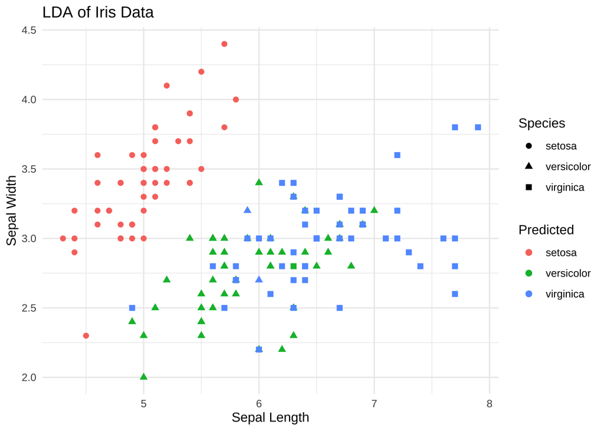

```r
# 预测类别
predictions <- predict(lda_result)$class

# 将预测结果添加到数据框中
data$Predicted <- predictions

# 可视化判别结果
ggplot(data, aes(x = Sepal.Length, y = Sepal.Width, color = Predicted, shape = Species)) +
  geom_point(size = 2) +
  labs(title = "LDA of Iris Data", x = "Sepal Length", y = "Sepal Width") +
  theme_minimal()
```

### 结果解释

- **判别函数**：通过`lda()`函数生成的判别函数，用于将样本分配到最可能的类别中。结果中包括每个类别的均值、判别系数等信息。
- **分类结果**：使用`predict()`函数可以对新样本进行分类。通过将预测类别与真实类别进行比较，可以评估分类的准确性。
- **可视化结果**：通过散点图展示不同类别的数据分布，使用不同颜色表示模型预测的类别，使用不同形状表示真实的类别，以直观地评估分类效果。

## 7 小结

- 判别分析是一种用于分类的统计方法，旨在通过构建判别函数将样本分配到已知类别中。
- 适用于分类任务，特别是多类分类问题，并且假设数据服从正态分布。
- 具有简单易用、多类分类和数据降维的优点，但对正态性和协方差矩阵相同的假设较为敏感。
- 可以通过R中的`lda()`函数实现判别分析，并结合可视化直观地展示分类结果。
- 在医学、市场营销、金融和生态学等领域，判别分析是一种重要的工具，用于样本分类和模式识别。